# 주거환경 만족도 영향요인 분석

## :직방 아파트 리뷰 데이터와 BERT 모형을 활용하여

###### 텍스트기반 경제사회 빅데이터 분석 도시공학과 2022249754 권준현

본 연구는 직방의 **아파트 리뷰 데이터**를 수집하고 딥러닝 기반의 자연어 처리 모형인 **BERT**와 기계학습 방법론인**SHAPley Value** 등을 활용하여 주거환경 만족도의 영향요인을 분석하였다. 구체적으로는 아파트 리뷰의 내용을 바탕으로 주거환경 만족도의 긍정적, 부정적 영향 요인을 도출하고 서울 시 내 권역별로 나타나는 차이를 비교하였으며, 이들의 연관어를 도출해 주거환경 만족도 개선을 위한 주요 사항을 제시하였다.

### '주거환경'이란?

###### 주거와 생활 장소를 둘러싸고 있는 생활환경의 총체로, 물리적 환경 및 사회적, 경제적, 문화적 환경을 모두 포함하는 개념 (아사미 야스시, 2003)

### '주거환경 만족도'란?

###### 사람들이 주관적으로 체험하는 주거환경 만족도는 사회적, 물리적 환경에 대한 정서적인 반응으로, 거주 가능성과 도시의 지속가능성 등을 판단하는 주요한 지표로 작용함 (신은진·남진, 2012; 안용진, 2016)

### '아파트'는?

###### 아파트는 주거생활의 총체적 경험을 제공하며, 가장 보편적인 주거형태임 (이유재·문선희, 2016)

###### 최근 온라인 서비스를 통해 아파트를 포함한 다양한 부동산 유형에 대한 정보를 쉽게 확인 가능하며, 더 나아가 웹 크롤링, 텍스트 마이닝을 통해 주거환경 만족도의 영향요인 분석, 부동산 임대료 예측 모형 개발 등이 가능 (김보찬 외, 2018; 김선재·이수기, 2020)

## 본 연구는?

### 아파트 리뷰 빅데이터를 활용해 주거환경 만족도 영향요인을 분석함

*설문조사로 구축한 정량적인 자료만을 활용, 조사자가 정한 항목만을 고려, 수동적으로 주거환경 만족도의 영향요인을 도출한 기존 연구와 딜리 본 연구는 다음과 같은 차별성을 지님*

**① 서울특별시 전체 아파트를 대상으로 주거환경 만족도를 수집**

**② 딥러닝 자연어처리 모델 활용, 만족도의 긍정적, 부정적 영향요인 자동 추출**

**③ 서울특별시 다섯 개 권역*에 따른 주거환경 만족도 영향요인 도출 및 분석**

## 본 연구의 프레임워크

[figure not shown]

<텍스트리뷰 전처리 예시>

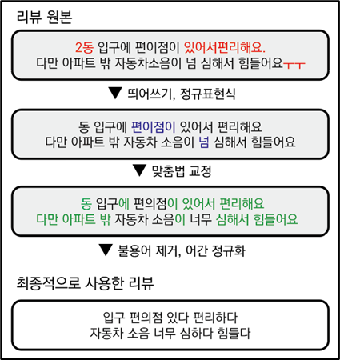

<BERT 활용 방법>

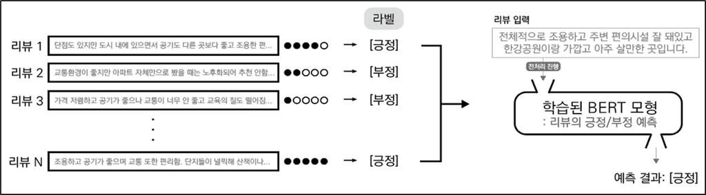

<Shap 활용 예시>

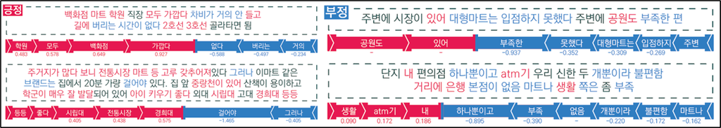

## 주요결과요약

아래 그림은 각 권역별로 도출된 영향요인 중 긍정적/부정적 영향요인에 대해 상위 5개 요인과 이를 바탕으로 도출한 주요 주제를 나타낸 것임

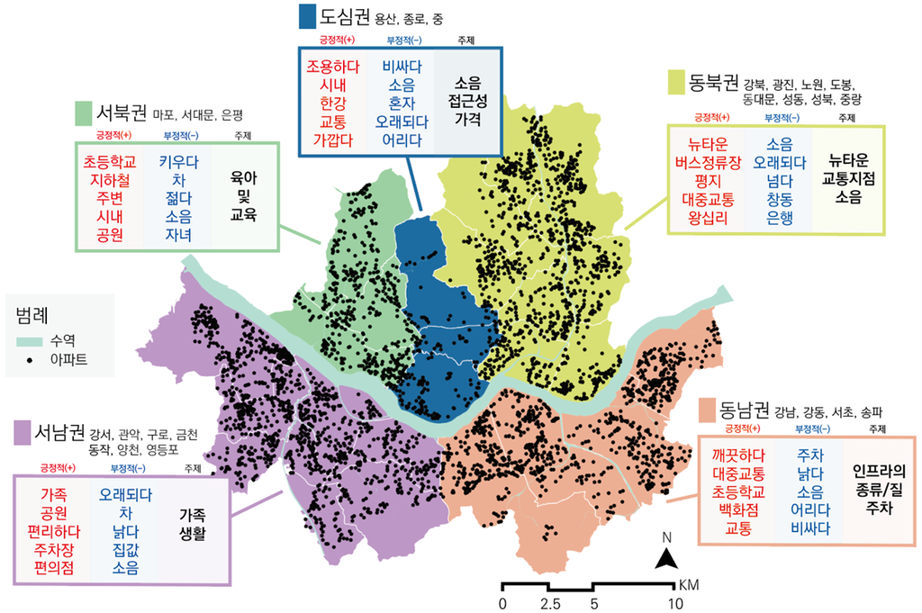

다음 그림은 각 권역에서 한 번이라도 도출된 상위 영향요인들에 대해, 서울 전체 리뷰에 대한 상대적 영향력과 연관어를 시각화한 것임

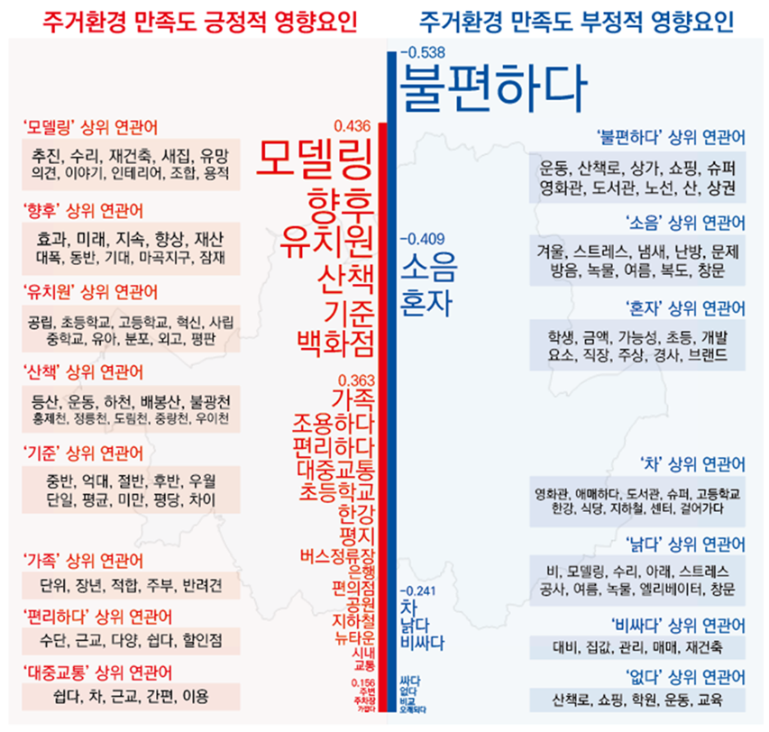

### 연구 결론

- 첫째, 서울 전체적으로 아파트의 경제적 가치가 주거환경 만족도에 영향을 미침
- 둘째, 도출된 주거환경 만족도 영향요인을 고려하여 권역별 다른 계획 수립이 가능
- 셋째, 아파트 리뷰를 활용한 인프라 요소 및 사람들 관심사의 모니터링이 가능

### 향후 진행 방향

- 한글 언어 전처리 정교화(인터넷 용어, 오탈자, 어간 정규화 등에서 오는 오류 등)
- 한글에 적합한 BERT 모형 토크나이저 검증 및 적용
- 리뷰 작성자의 개인적 특성 및 공간 단위의 규모 고려
- 리뷰 작성 시점 구분하여 분석(데이터 편향 고려)